# ENV 790.30 - Time Series Analysis for Energy Data | Spring 2023

Assignment 6 - Due date 03/06/23

Caroline Ren

## Directions

You should open the .rmd file corresponding to this assignment on RStudio. The file is available on our class repository on Github. And to do so you will need to fork our repository and link it to your RStudio.

Once you have the file open on your local machine the first thing you will do is rename the file such that it includes your first and last name (e.g., “LuanaLima_TSA_A06_Sp23.Rmd”). Then change “Student Name” on line 4 with your name.

Then you will start working through the assignment by **creating code and output** that answer each question. Be sure to use this assignment document. Your report should contain the answer to each question and any plots/tables you obtained (when applicable).

When you have completed the assignment, **Knit** the text and code into a single PDF file. Submit this pdf using Sakai.

R packages needed for this assignment: “xlsx” or “readxl”, “ggplot2”, “forecast”,“tseries”, and “Kendall”. Install these packages, if you haven’t done yet. Do not forget to load them before running your script, since they are NOT default packages.

## Questions

This assignment has general questions about ARIMA Models.

Packages needed for this assignment: “forecast”,“tseries”. Do not forget to load them before running your script, since they are NOT default packages.\

```r
#Load/install required package here
library(forecast)
library(tseries)
```

## Q1

Describe the important characteristics of the sample autocorrelation function (ACF) plot and the partial sample autocorrelation function (PACF) plot for the following models:

- AR(2)

> Answer: For AR models, ACF will decay exponentially with time. The PACF will identify the order of the AR model.
- MA(1)

> Answer: For MA models ACF will identify the order of the MA model. The PACF will decay exponentially.

## Q2

Recall that the non-seasonal ARIMA is described by three parameters ARIMA$(p,d,q)$ where $p$ is the order of the autoregressive component, $d$ is the number of times the series need to be differenced to obtain stationarity and $q$ is the order of the moving average component. If we don’t need to difference the series, we don’t need to specify the “I” part and we can use the short version, i.e., the ARMA$(p,q)$. Consider three models: ARMA(1,0), ARMA(0,1) and ARMA(1,1) with parameters $\phi=0.6$ and $\theta= 0.9$. The $\phi$ refers to the AR coefficient and the $\theta$ refers to the MA coefficient. Use R to generate $n=100$ observations from each of these three models

```r
#ARMA(1,0)

ARMAmodel_1<- arima.sim(model=list(ar=0.6), n=100) #the AR coefficient is 0.6

#ARMA(0,1)

ARMAmodel_2<- arima.sim(model=list(ma=0.9), n=100) #the MA coefficient is 0.9

#ARMA(1,1)
ARMAmodel_3<- arima.sim(model=list(ar=0.6, ma=0.9), n=100)
#the AR coefficient is 0.6,the MA coefficient is 0.9
```

1. Plot the sample ACF for each of these models in one window to facilitate comparison (Hint: use command $par(mfrow=c(1,3))$ that divides the plotting window in three columns).

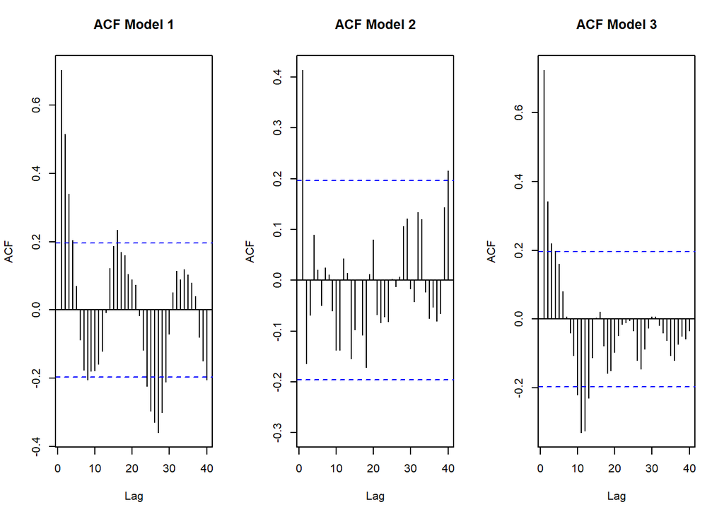

```r
par(mfrow=c(1,3))
ACF_Plot <- Acf(ARMAmodel_1, lag = 40,
                main = "ACF Model 1")
ACF_Plot <- Acf(ARMAmodel_2, lag = 40,
                main = "ACF Model 2")
ACF_Plot <- Acf(ARMAmodel_3, lag = 40,
                main = "ACF Model 3")
```

2. Plot the sample PACF for each of these models in one window to facilitate comparison.

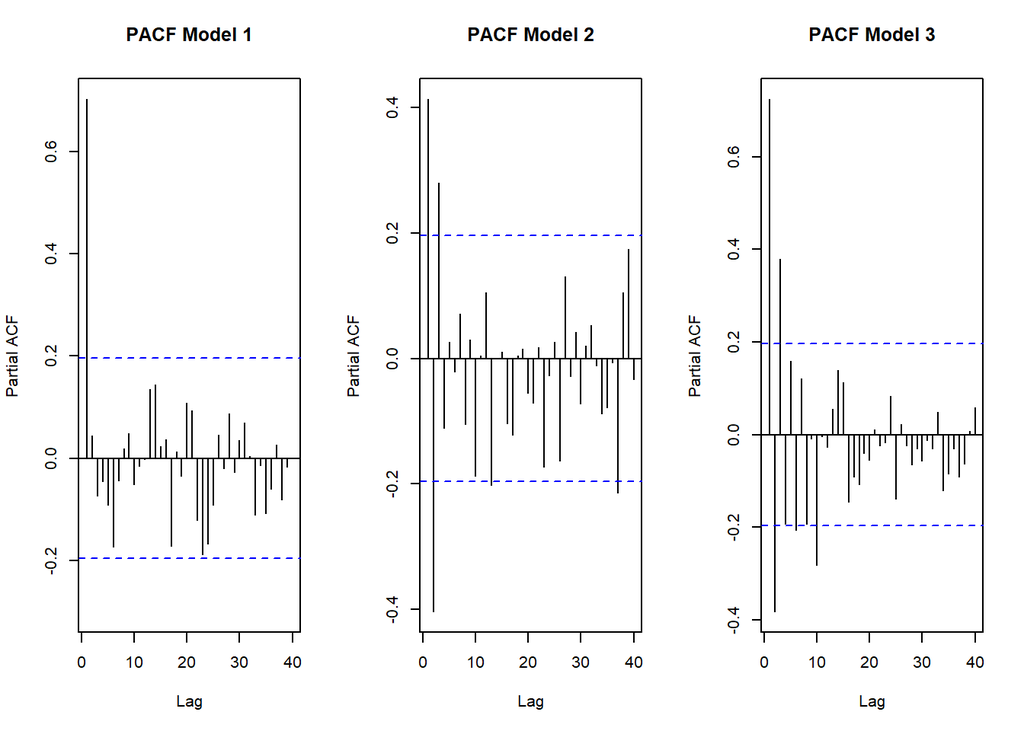

```r
par(mfrow=c(1,3))
PACF_Plot <- Pacf(ARMAmodel_1, lag = 40,
                  main = "PACF Model 1")
PACF_Plot <- Pacf(ARMAmodel_2, lag = 40,
                  main = "PACF Model 2")
PACF_Plot <- Pacf(ARMAmodel_3, lag = 40,
                  main = "PACF Model 3")
```

3. Look at the ACFs and PACFs. Imagine you had these plots for a data set and you were asked to identify the model, i.e., is it AR, MA or ARMA and the order of each component. Would you be identify them correctly? Explain your answer.

```r
Model_autofit <- auto.arima(ARMAmodel_1)
print(Model_autofit)
```

```
## Series: ARMAmodel_1
## ARIMA(1,0,0) with zero mean
##
## Coefficients:
##          ar1
##       0.7203
## s.e.  0.0679
##
## sigma^2 = 1.023:  log likelihood = -142.87
## AIC=289.74   AICc=289.86   BIC=294.95
```

```r
Model_autofit <- auto.arima(ARMAmodel_2)
print(Model_autofit)
```

```
## Series: ARMAmodel_2
## ARIMA(0,0,1) with zero mean
##
## Coefficients:
##          ma1
##       0.9085
## s.e.  0.0442
##
## sigma^2 = 0.7952:  log likelihood = -130.8
## AIC=265.61   AICc=265.73   BIC=270.82
```

```r
Model_autofit <- auto.arima(ARMAmodel_3)
print(Model_autofit)
```

```
## Series: ARMAmodel_3
## ARIMA(1,0,1) with zero mean
##
## Coefficients:
##          ar1     ma1
##       0.4734  0.9098
## s.e.  0.0903  0.0484
##
## sigma^2 = 0.8651:  log likelihood = -135
## AIC=276.01   AICc=276.26   BIC=283.82
```

```r
#ARMA(1,0)

ARMAmodel2_1<- arima.sim(model=list(ar=0.6), n=1000) #the AR coefficient is 0.6

#ARMA(0,1)

ARMAmodel2_2<- arima.sim(model=list(ma=0.9), n=1000) #the MA coefficient is 0.9

#ARMA(1,1)
ARMAmodel2_3<- arima.sim(model=list(ar=0.6, ma=0.9), n=1000)
#the AR coefficient is 0.6,the MA coefficient is 0.9
```

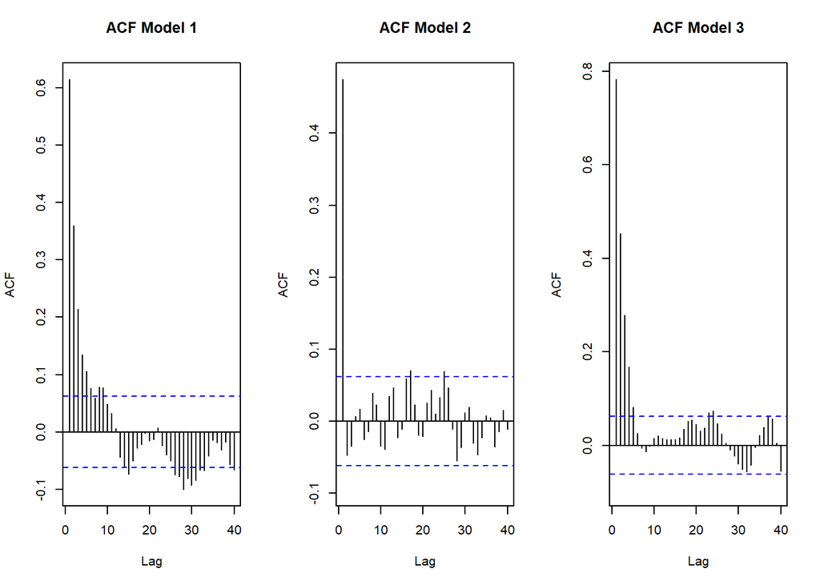

```r
par(mfrow=c(1,3))
ACF_Plot <- Acf(ARMAmodel2_1, lag = 40,
                main = "ACF Model 1")
ACF_Plot <- Acf(ARMAmodel2_2, lag = 40,
                main = "ACF Model 2")
ACF_Plot <- Acf(ARMAmodel2_3, lag = 40,
                main = "ACF Model 3")
```

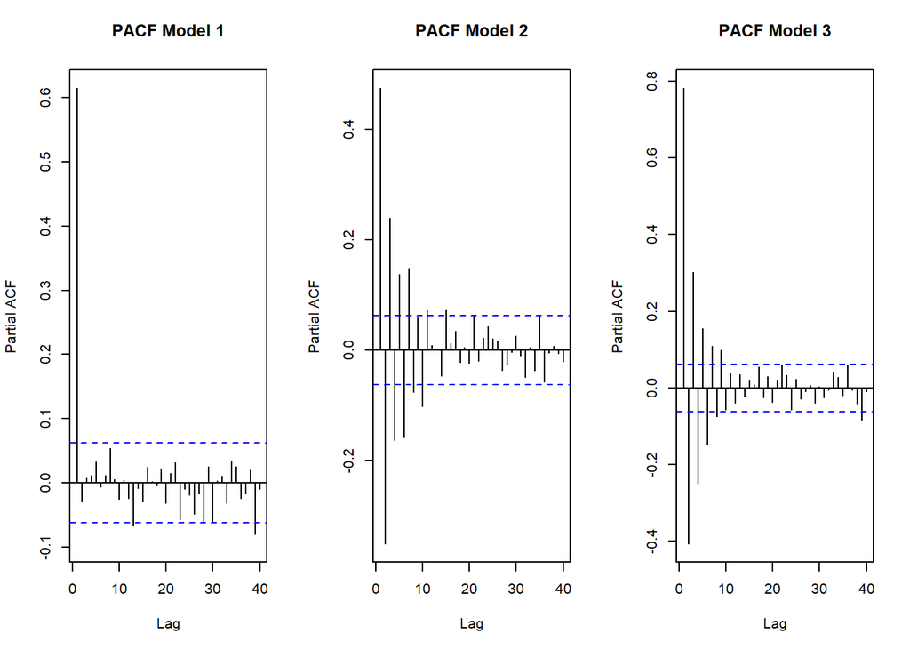

```r
par(mfrow=c(1,3))
PACF_Plot <- Pacf(ARMAmodel2_1, lag = 40,
                  main = "PACF Model 1")
PACF_Plot <- Pacf(ARMAmodel2_2, lag = 40,
                  main = "PACF Model 2")
PACF_Plot <- Pacf(ARMAmodel2_3, lag = 40,
                  main = "PACF Model 3")
```

```r
Model_autofit <- auto.arima(ARMAmodel2_1)
print(Model_autofit)
```

```
## Series: ARMAmodel2_1
## ARIMA(1,0,0) with zero mean
##
## Coefficients:
##          ar1
##       0.6139
## s.e.  0.0249
##
## sigma^2 = 0.9959:  log likelihood = -1416.62
## AIC=2837.24   AICc=2837.25   BIC=2847.05
```

```r
Model_autofit <- auto.arima(ARMAmodel2_2)
print(Model_autofit)
```

```
## Series: ARMAmodel2_2
## ARIMA(2,0,1) with zero mean
##
## Coefficients:
##           ar1      ar2     ma1
##       -0.0078  -0.0364  0.9007
## s.e.   0.0359   0.0352  0.0175
##
## sigma^2 = 0.9545:  log likelihood = -1395.02
## AIC=2798.04   AICc=2798.08   BIC=2817.67
```

```r
Model_autofit <- auto.arima(ARMAmodel2_3)
print(Model_autofit)
```

```
## Series: ARMAmodel2_3
## ARIMA(1,0,1) with zero mean
##
## Coefficients:
##          ar1     ma1
##       0.5632  0.8968
## s.e.  0.0269  0.0143
##
## sigma^2 = 0.9588:  log likelihood = -1398.34
## AIC=2802.68   AICc=2802.7   BIC=2817.4
```

## Q3

Consider the ARIMA model $y_t=0.7*y_{t-1}-0.25*y_{t-12}+a_t-0.1*a_{t-1}$

1. Identify the model using the notation ARIMA$(p,d,q)(P,D,Q)_ s$, i.e., identify the integers $p,d,q,P,D,Q,s$ (if possible) from the equation.

p = 1, d=0, q=1. P=1, D=0, Q=0 s=12

2. Also from the equation what are the values of the parameters, i.e., model coefficients. phi=0.7, theta=0.1, seasonal phi=0.25

## Q4

Plot the ACF and PACF of a seasonal ARIMA$(0, 1)\times(1, 0)_{12}$ model with $\phi =0 .8$ and $\theta = 0.5$ using R. The $12$ after the bracket tells you that $s=12$, i.e., the seasonal lag is 12, suggesting monthly data whose behavior is repeated every 12 months. You can generate as many observations as you like. Note the Integrated part was omitted. It means the series do not need differencing, therefore $d=D=0$. Plot ACF and PACF for the simulated data. Comment if the plots are well representing the model you simulated, i.e., would you be able to identify the order of both non-seasonal and seasonal components from the plots? Explain.

```r
#install.packages("sarima")

library(sarima)
```

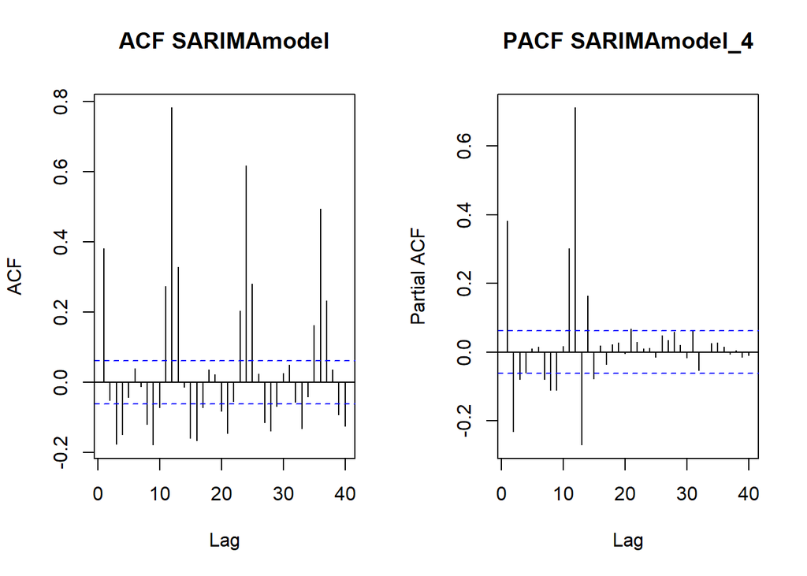

```r
SARIMAmodel_4<- sim_sarima(model=list(ma=0.5,sar=0.8, nseasons=12), n=1000)

par(mfrow=c(1,2))
ACF_Plot <- Acf(SARIMAmodel_4, lag = 40,
                main = "ACF SARIMAmodel")
ACF_Plot <- Pacf(SARIMAmodel_4, lag = 40,
                main = "PACF SARIMAmodel_4")
```